# Explanatory analysis of a GEO dataset

Paula Balcells

May 15, 2019

# Introduction

The goal of this practical is to learn the basics of Bioconductor and Rmarkdown. Fo rhis purpose, we are going to work on a study from the Gene Expression Omnibus Database.

The study selected is “Insights into responses of human astrocytes to H5N1 infection by transcriptional analysis” with GEO accession code GSE66597.We have used the expression matrix, the experiment description and the experimental groups from this study.

The ExpressionSet object is created using two different methodologies:

- Creating and assembling the different components
- Using GEOquery package

# Summary

The study “Insights into responses of human astrocytes to H5N1 infection by transcriptional analysis” was done using Homo Sapiens organisms and experiment type Expression profiling by array.

The following description was provided: *Increasing evidence demonstrates influenza virus can not only affect the respiratory system, but also infect CNS and lead to CNS disorder and encephalopathy and encephalitis. Astrocytes are the most abundant cells in the CNS, which are capable of producing cytokines and neurotrophic factors and are essential for brain homeostasis and neuronal function. Previous studies suggested that influenza virus can infect astrocytes and induce proinflammatory cytokines response as well as apoptosis. Nevertheless, very few mechanistic data are available regarding host responses to H5N1 infection in astrocytes. In this study, a functional genomics approach was utilized to investigate comprehensive host responses to H5N1 infection in a human astrocyte cell line, U251 cells.*

## Experimental design

U251 cells were infected by H5N1 at MOI 1 or control . At time points 6, 12, and 24h, total RNA were extracted for microarray experiment. Three replicates were performed at each time point of infection and control infection.

## Platform

GPL6480: Agilent-014850 Whole Human Genome Microarray 4x44K G4112F (Probe Name version)

## Status

Public on Jan 04, 2016

## Contributor(s)

Lin X, Wang R, Sun X, Zhang J, Jin M

## Citation(s)

Lin X, Wang R, Zhang J, Sun X et al. Insights into Human Astrocyte Response to H5N1 Infection by Microarray Analysis. Viruses 2015 May 22;7(5):2618-40. PMID: 26008703

# Data description

```r
targets <- read.csv("targets.txt", sep="")
expressions <- read.delim("GSE66597_expression.txt", row.names = 1)
genes <- t(expressions)[0,]
```

```r
info=list(myName="Paula Balcells", myLab="BDBI Omics Techniques",
myContact="paulabalcells@gmail.com.com", myTitle="Practical Exercise on ExpressionSets")
```

Expression values: matrix of 41091 rows and 18 columns. Covariates: sampleName, Group, Replicate, Color. Genes: identifiers of the genes in the column 0 of the expression values matrix.

```r
dim(expressions)
```

```
## [1] 41091    18
```

```r
summary(expressions)
```

```
##    GSM1625995       GSM1625996       GSM1625997       GSM1625998
##  Min.   : 1.820   Min.   : 1.820   Min.   : 1.820   Min.   : 1.820
##  1st Qu.: 4.232   1st Qu.: 4.232   1st Qu.: 4.232   1st Qu.: 4.232
##  Median : 6.854   Median : 6.854   Median : 6.854   Median : 6.854
##  Mean   : 6.992   Mean   : 6.992   Mean   : 6.992   Mean   : 6.992
##  3rd Qu.: 9.410   3rd Qu.: 9.410   3rd Qu.: 9.410   3rd Qu.: 9.410
##  Max.   :18.589   Max.   :18.589   Max.   :18.589   Max.   :18.589
##    GSM1625999       GSM1626000       GSM1626001       GSM1626002
##  Min.   : 1.820   Min.   : 1.820   Min.   : 1.820   Min.   : 1.820
##  1st Qu.: 4.232   1st Qu.: 4.232   1st Qu.: 4.232   1st Qu.: 4.232
##  Median : 6.854   Median : 6.854   Median : 6.854   Median : 6.854
##  Mean   : 6.992   Mean   : 6.992   Mean   : 6.992   Mean   : 6.992
##  3rd Qu.: 9.410   3rd Qu.: 9.410   3rd Qu.: 9.410   3rd Qu.: 9.410
##  Max.   :18.589   Max.   :18.589   Max.   :18.589   Max.   :18.589
##    GSM1626003       GSM1626004       GSM1626005       GSM1626006
##  Min.   : 1.820   Min.   : 1.820   Min.   : 1.820   Min.   : 1.820
##  1st Qu.: 4.232   1st Qu.: 4.232   1st Qu.: 4.232   1st Qu.: 4.232
##  Median : 6.854   Median : 6.854   Median : 6.854   Median : 6.854
##  Mean   : 6.992   Mean   : 6.992   Mean   : 6.992   Mean   : 6.992
##  3rd Qu.: 9.410   3rd Qu.: 9.410   3rd Qu.: 9.410   3rd Qu.: 9.410
##  Max.   :18.589   Max.   :18.589   Max.   :18.589   Max.   :18.589
##    GSM1626007       GSM1626008       GSM1626009       GSM1626010
##  Min.   : 1.820   Min.   : 1.820   Min.   : 1.820   Min.   : 1.820
##  1st Qu.: 4.232   1st Qu.: 4.232   1st Qu.: 4.232   1st Qu.: 4.232
##  Median : 6.854   Median : 6.854   Median : 6.854   Median : 6.854
##  Mean   : 6.992   Mean   : 6.992   Mean   : 6.992   Mean   : 6.992
##  3rd Qu.: 9.410   3rd Qu.: 9.410   3rd Qu.: 9.410   3rd Qu.: 9.410
##  Max.   :18.589   Max.   :18.589   Max.   :18.589   Max.   :18.589
##    GSM1626011       GSM1626012
##  Min.   : 1.820   Min.   : 1.820
##  1st Qu.: 4.232   1st Qu.: 4.232
##  Median : 6.854   Median : 6.854
##  Mean   : 6.992   Mean   : 6.992
##  3rd Qu.: 9.410   3rd Qu.: 9.410
##  Max.   :18.589   Max.   :18.589
```

Plotting the data:

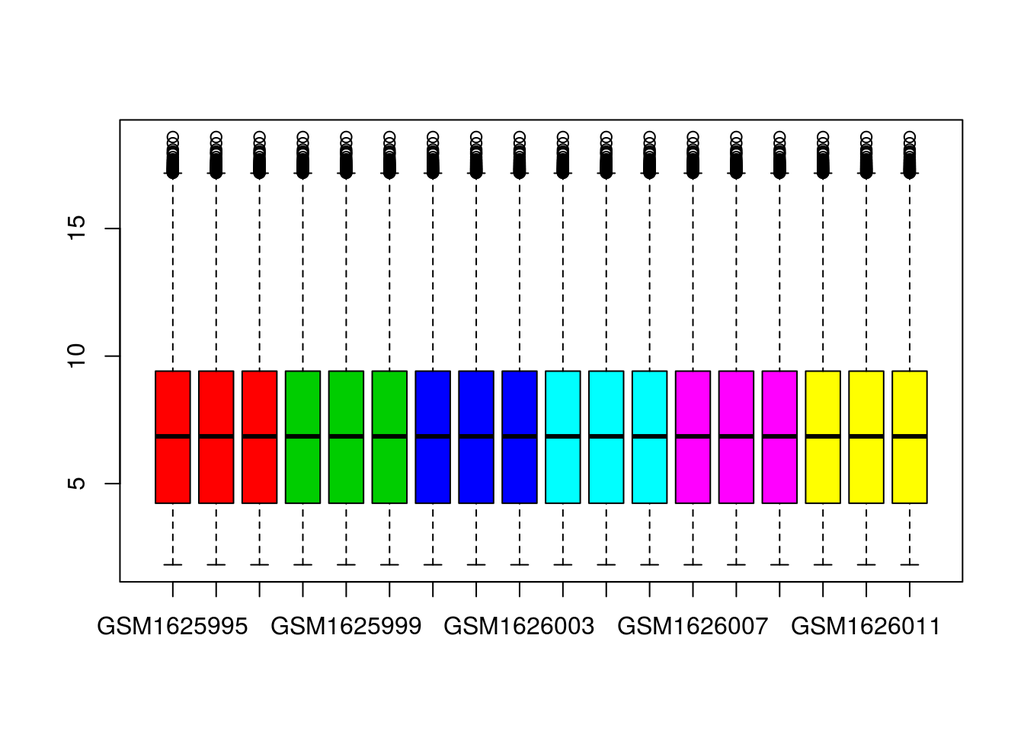

```r
boxplot(expressions, col=targets$Color)
```

Principal components analysis:

```r
pcs <- prcomp(expressions)
names(pcs)
```

```
## [1] "sdev"     "rotation" "center"   "scale"    "x"
```

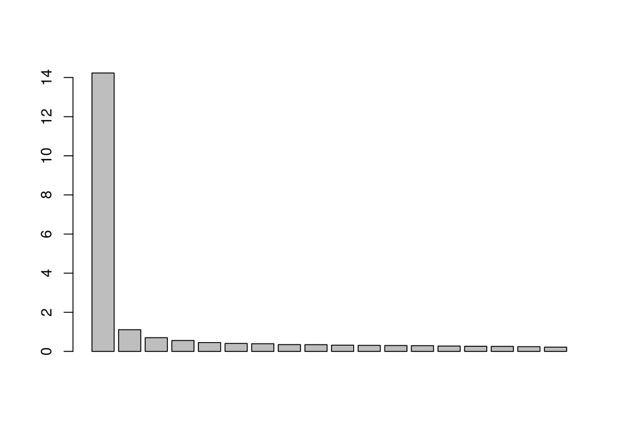

```r
barplot(pcs$sdev)
```

The top variable genes are:

```r
variab <- apply(expressions, 1, sd)
orderedGenes <- genes[order(variab, decreasing=TRUE)]
head(variab[order(variab, decreasing=TRUE)])
```

```
##  A_23_P95879 A_32_P480330 A_32_P461976 A_32_P302205 A_23_P304509
##     3.374662     2.816269     2.801871     2.789320     2.632833
##  A_23_P84246
##     2.590745
```

# ExpressionSet

The ExpressionSet class contains the following slots:

- assayData: Matrix of expression measures, genes x samples
- phenoData: Sample level covariates, instance of class annotatedDataFrame
- Annotation: Name of annotation data source (annotation package)
- featureData: Name of features = data identifiers
- experimentData: MIAME information
- notes: Any notes

## AssayData

The assay data slot contains a matrix of with the expression values. There are as many rows as genes and as many columns as samples.

```r
expressions <- as.matrix(expressions)
set <- ExpressionSet(expressions)
show(set)
```

```
## ExpressionSet (storageMode: lockedEnvironment)
## assayData: 41091 features, 18 samples
##   element names: exprs
## protocolData: none
## phenoData: none
## featureData: none
## experimentData: use 'experimentData(object)'
## Annotation:
```

## Information about covariates

```r
columnDesc <-  data.frame(labelDescription= c("Sample Name", "Group", "Replicate", "Color"))
annot <- new("AnnotatedDataFrame", data=targets, varMetadata= columnDesc)
show(annot)
```

```
## An object of class 'AnnotatedDataFrame'
##   rowNames: 1 2 ... 18 (18 total)
##   varLabels: sampleName Group Replicate Color
##   varMetadata: labelDescription
```

Add the annotated data frame to the expression set.

```r
rownames(pData(annot))<-pData(annot)$sampleName
set <- ExpressionSet(assayData=expressions, phenoData=annot)
show(set)
```

```
## ExpressionSet (storageMode: lockedEnvironment)
## assayData: 41091 features, 18 samples
##   element names: exprs
## protocolData: none
## phenoData
##   sampleNames: GSM1625995 GSM1625996 ... GSM1626012 (18 total)
##   varLabels: sampleName Group Replicate Color
##   varMetadata: labelDescription
## featureData: none
## experimentData: use 'experimentData(object)'
## Annotation:
```

## Information about features

The information about the genes can be stored in the featureData slot, also as an AnnotatedDataFrame.

```r
set <- ExpressionSet(assayData=expressions,
phenoData=annot,
featureNames =genes)
show(set)
```

```
## ExpressionSet (storageMode: lockedEnvironment)
## assayData: 41091 features, 18 samples
##   element names: exprs
## protocolData: none
## phenoData
##   sampleNames: GSM1625995 GSM1625996 ... GSM1626012 (18 total)
##   varLabels: sampleName Group Replicate Color
##   varMetadata: labelDescription
## featureData: none
## experimentData: use 'experimentData(object)'
## Annotation:
```

## Information about the experiment

The information about the experiment can be stored in the experimentData slot, as MIAME information.

```r
descExp <- new("MIAME", name= info[["myName"]],
lab= info[["myLab"]],
contact= info[["myContact"]] ,
title=info[["myTitle"]])

set <- ExpressionSet(assayData=expressions, phenoData=annot, fetureNames=genes, experimentData=descExp)

show(set)
```

```
## ExpressionSet (storageMode: lockedEnvironment)
## assayData: 41091 features, 18 samples
##   element names: exprs
## protocolData: none
## phenoData
##   sampleNames: GSM1625995 GSM1625996 ... GSM1626012 (18 total)
##   varLabels: sampleName Group Replicate Color
##   varMetadata: labelDescription
## featureData: none
## experimentData: use 'experimentData(object)'
## Annotation:
```

## Objects of class ExpressionSet

Data in an ExpressionSet can be managed for different purposes, with consistency within the class ensured. It is possible to acces slot values as well as subsetting the ExpressionSet, for example.

```r
dim(exprs(set))
```

```
## [1] 41091    18
```

```r
class(phenoData(set))
```

```
## [1] "AnnotatedDataFrame"
## attr(,"package")
## [1] "Biobase"
```

```r
class(pData(phenoData(set)))
```

```
## [1] "data.frame"
```

```r
head(pData(phenoData(set)))
```

```
##            sampleName  Group Replicate Color
## GSM1625995 GSM1625995  con6h      rep1     2
## GSM1625996 GSM1625996  con6h      rep2     2
## GSM1625997 GSM1625997  con6h      rep3     2
## GSM1625998 GSM1625998 con12h      rep1     3
## GSM1625999 GSM1625999 con12h      rep2     3
## GSM1626000 GSM1626000 con12h      rep3     3
```

```r
head(pData(set))
```

```
##            sampleName  Group Replicate Color
## GSM1625995 GSM1625995  con6h      rep1     2
## GSM1625996 GSM1625996  con6h      rep2     2
## GSM1625997 GSM1625997  con6h      rep3     2
## GSM1625998 GSM1625998 con12h      rep1     3
## GSM1625999 GSM1625999 con12h      rep2     3
## GSM1626000 GSM1626000 con12h      rep3     3
```

### Subsetting ExpressionSet

We are going to subset the ExpressionSet into the different groups of the experiment accounting for the targets covariates.

```r
con6hSet <- set[,pData(set)$Group=="con6h"]
con12hSet <- set[,pData(set)$Group=="con12h"]
con24hSet <- set[,pData(set)$Group=="con24h"]
hm6hSet <- set[,pData(set)$Group=="hm6h"]
hm12hSet <- set[,pData(set)$Group=="hm12h"]
hm24hSet <- set[,pData(set)$Group=="hm24h"]

dim(exprs(con6hSet))
```

```
## [1] 41091     3
```

```r
head(pData(con6hSet))
```

```
##            sampleName Group Replicate Color
## GSM1625995 GSM1625995 con6h      rep1     2
## GSM1625996 GSM1625996 con6h      rep2     2
## GSM1625997 GSM1625997 con6h      rep3     2
```

```r
all(colnames(exprs(con6hSet))==rownames(pData(con6hSet)))
```

```
## [1] TRUE
```

```r
all(colnames(exprs(hm6hSet))==rownames(pData(hm6hSet)))
```

```
## [1] TRUE
```

# Data grom GEO

The GEO set that has been studied along the report corresponds to accession code in NCBI GEO GSE66597.

We can use the package GEOquery to retrieve the data.

```r
gse <- getGEO("GSE66597")
```

```
## Found 1 file(s)
```

```
## GSE66597_series_matrix.txt.gz
```

```
## File stored at:
```

```
## /tmp/RtmptgJUkA/GPL6480.soft
```

We can access the ExpressionSet object from the “gse” list.

```r
class(gse)
```

```
## [1] "list"
```

```r
names(gse)
```

```
## [1] "GSE66597_series_matrix.txt.gz"
```

```r
setFromGeo <- gse[[1]]
class(setFromGeo)
```

```
## [1] "ExpressionSet"
## attr(,"package")
## [1] "Biobase"
```

# Github repository

https://github.com/balpaula/Balcells_Paula-OmicsTechniques